# Back to Titanic

### Stop searching for Heart of the Ocean 💎, let's find out the diamond rule of survival

Let's go back to the Titanic tragedy with Python. We will use machine learning tools to find out what determined the survival rate of the passengers on this giant ship. Titanic dataset is the first and must dataset that every data scientist haved met in their early career. This time I would re-investigate Titanic Survival dataset after 2 years learning in the world of data science.

```python
import pandas as pd
import numpy as np
import random as rnd

# visualization
import seaborn as sns
import matplotlib.pyplot as plt
%matplotlib inline

# machine learning
from sklearn.linear_model import LogisticRegression
from sklearn.svm import SVC, LinearSVC
from sklearn.ensemble import RandomForestClassifier
from sklearn.neighbors import KNeighborsClassifier
from sklearn.naive_bayes import GaussianNB
from sklearn.linear_model import Perceptron
from sklearn.linear_model import SGDClassifier
from sklearn.tree import DecisionTreeClassifier
```

```python
train_df = pd.read_csv('train.csv')
test_df = pd.read_csv('test.csv')
combine = [train_df, test_df]
```

```python
print(train_df.columns.values)
```

```
['PassengerId' 'Survived' 'Pclass' 'Name' 'Sex' 'Age' 'SibSp' 'Parch'
 'Ticket' 'Fare' 'Cabin' 'Embarked']
```

```python
train_df.info()
print('_'*40)
test_df.info()
```

```
<class 'pandas.core.frame.DataFrame'>
RangeIndex: 891 entries, 0 to 890
Data columns (total 12 columns):
PassengerId    891 non-null int64
Survived       891 non-null int64
Pclass         891 non-null int64
Name           891 non-null object
Sex            891 non-null object
Age            714 non-null float64
SibSp          891 non-null int64
Parch          891 non-null int64
Ticket         891 non-null object
Fare           891 non-null float64
Cabin          204 non-null object
Embarked       889 non-null object
dtypes: float64(2), int64(5), object(5)
memory usage: 83.6+ KB
________________________________________
<class 'pandas.core.frame.DataFrame'>
RangeIndex: 418 entries, 0 to 417
Data columns (total 11 columns):
PassengerId    418 non-null int64
Pclass         418 non-null int64
Name           418 non-null object
Sex            418 non-null object
Age            332 non-null float64
SibSp          418 non-null int64
Parch          418 non-null int64
Ticket         418 non-null object
Fare           417 non-null float64
Cabin          91 non-null object
Embarked       418 non-null object
dtypes: float64(2), int64(4), object(5)
memory usage: 36.0+ KB
```

```python
#Total Survived rate
```

```python
pd.crosstab(index = train_df["Survived"],
                              columns="count")
```

| col_0 Survived | count |
| --- | --- |
| 0 | 549 |
| 1 | 342 |

```python
### How is the Summary Statistics
train_df.describe()
```

|  | PassengerId | Survived | Pclass | Age | SibSp | Parch | Fare |
| --- | --- | --- | --- | --- | --- | --- | --- |
| count | 891.000000 | 891.000000 | 891.000000 | 714.000000 | 891.000000 | 891.000000 | 891.000000 |
| mean | 446.000000 | 0.383838 | 2.308642 | 29.699118 | 0.523008 | 0.381594 | 32.204208 |
| std | 257.353842 | 0.486592 | 0.836071 | 14.526497 | 1.102743 | 0.806057 | 49.693429 |
| min | 1.000000 | 0.000000 | 1.000000 | 0.420000 | 0.000000 | 0.000000 | 0.000000 |
| 25% | 223.500000 | 0.000000 | 2.000000 | 20.125000 | 0.000000 | 0.000000 | 7.910400 |
| 50% | 446.000000 | 0.000000 | 3.000000 | 28.000000 | 0.000000 | 0.000000 | 14.454200 |
| 75% | 668.500000 | 1.000000 | 3.000000 | 38.000000 | 1.000000 | 0.000000 | 31.000000 |
| max | 891.000000 | 1.000000 | 3.000000 | 80.000000 | 8.000000 | 6.000000 | 512.329200 |

### Let's Explore the Features we have!

```python
coverage = 891/2224; coverage
```

```
0.4006294964028777
```

```python
sum(train_df['Survived']==1)/len(train_df)
```

```
0.38383838383838381
```

```python
(2224-1502)/2224
```

```
0.32464028776978415
```

```python
sum(train_df['Parch']==0) / len(train_df)
```

```
0.76094276094276092
```

```python
sum(train_df['SibSp']!=0) / len(train_df)
```

```
0.31762065095398428
```

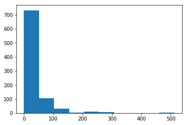

```python
plt.hist(train_df['Fare'])
```

**Does Fare paid matter ?**

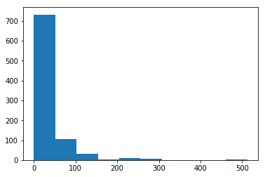

```python
plt.hist(train_df['Fare'])
```

From the graph above we can see that some transforming the variables is adivsable since the distribution of fare is screwed (to right). We would conduct the this process in data preprocessing.

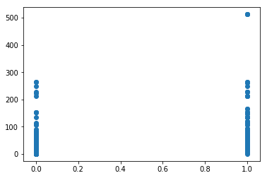

```python
plt.scatter(x = train_df['Survived'], y= train_df['Fare'])
```

Interestingly, only those who pay the most ( 512 dollars) is guaranteed to survive. Other premium passangers who pays above $200 has no significant difference.

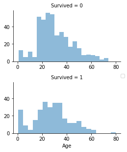

```python
grid = sns.FacetGrid(train_df, row='Survived', size=2.2, aspect=1.6)
grid.map(plt.hist, 'Age', alpha=.5, bins=20)
grid.add_legend()
```

### The distribution of numerical feature values across the training samples

This helps us determine, among other early insights, how representative is the training dataset of the actual problem domain.

[output not shown]

- Few elderly passengers (<1%) within age range 65-80.

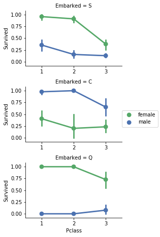

```python
# grid = sns.FacetGrid(train_df, col='Embarked')
grid = sns.FacetGrid(train_df, row='Embarked', size=2.2, aspect=1.6)
grid.map(sns.pointplot, 'Pclass', 'Survived', 'Sex', palette='deep')
grid.add_legend()
```

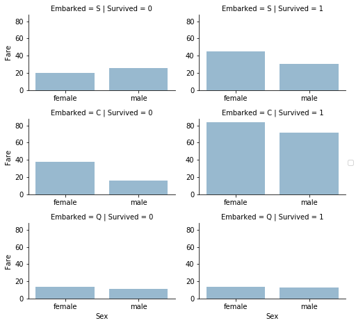

```python
grid = sns.FacetGrid(train_df, row='Embarked', col='Survived', size=2.2, aspect=1.6)
grid.map(sns.barplot, 'Sex', 'Fare', alpha=.5, ci=None)
grid.add_legend()
```

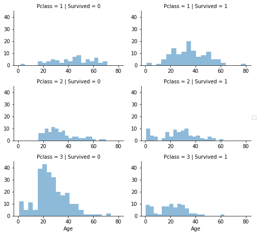

```python
grid = sns.FacetGrid(train_df, col='Survived', row='Pclass', size=2.2, aspect=1.6)
grid.map(plt.hist, 'Age', alpha=.5, bins=20)
grid.add_legend();
```

```python
# This can show the description categorical data of the df
train_df.describe(include=['O'])
```

|  | Name | Sex | Ticket | Cabin | Embarked |
| --- | --- | --- | --- | --- | --- |
| count | 891 | 891 | 891 | 204 | 889 |
| unique | 891 | 2 | 681 | 147 | 3 |
| top | Moor, Mrs. (Beila) | male | 1601 | B96 B98 | S |
| freq | 1 | 577 | 7 | 4 | 644 |

What is the distribution of categorical features?

- Names are unique across the dataset (count=unique=891)
- Sex variable as two possible values with 65% male (top=male, freq=577/count=891).
- Cabin values have several dupicates across samples. Alternatively several passengers shared a cabin.
- Embarked takes three possible values. S port used by most passengers (top=S) Ticket feature has high ratio (22%) of duplicate values (unique=681).

## Feature Engineering:Title Extracting

How to use the variable 'Name' wisely?

```python
for dataset in combine:
    dataset['Title'] = dataset.Name.str.extract(' ([A-Za-z]+)\.', expand=False)

pd.crosstab(train_df['Title'], train_df['Sex'])
```

| Sex Title | female | male |
| --- | --- | --- |
| Capt | 0 | 1 |
| Col | 0 | 2 |
| Countess | 1 | 0 |
| Don | 0 | 1 |
| Dr | 1 | 6 |
| Jonkheer | 0 | 1 |
| Lady | 1 | 0 |
| Major | 0 | 2 |
| Master | 0 | 40 |
| Miss | 182 | 0 |
| Mlle | 2 | 0 |
| Mme | 1 | 0 |
| Mr | 0 | 517 |
| Mrs | 125 | 0 |
| Ms | 1 | 0 |
| Rev | 0 | 6 |
| Sir | 0 | 1 |

```python
train_df[['Title', 'Survived']].groupby(['Title'], as_index=False).mean()
```

|  | Title | Survived |
| --- | --- | --- |
| 0 | Capt | 0.000000 |
| 1 | Col | 0.500000 |
| 2 | Countess | 1.000000 |
| 3 | Don | 0.000000 |
| 4 | Dr | 0.428571 |
| 5 | Jonkheer | 0.000000 |
| 6 | Lady | 1.000000 |
| 7 | Major | 0.500000 |
| 8 | Master | 0.575000 |
| 9 | Miss | 0.697802 |
| 10 | Mlle | 1.000000 |
| 11 | Mme | 1.000000 |
| 12 | Mr | 0.156673 |
| 13 | Mrs | 0.792000 |
| 14 | Ms | 1.000000 |
| 15 | Rev | 0.000000 |
| 16 | Sir | 1.000000 |

```python
for dataset in combine:
    dataset['Title'] = dataset['Title'].replace(['Lady', 'Countess','Capt', 'Col',\
 	'Don', 'Dr', 'Major', 'Rev', 'Sir', 'Jonkheer', 'Dona'], 'Rare')

    dataset['Title'] = dataset['Title'].replace('Mlle', 'Miss')
    dataset['Title'] = dataset['Title'].replace('Ms', 'Miss')
    dataset['Title'] = dataset['Title'].replace('Mme', 'Mrs')

train_df[['Title', 'Survived']].groupby(['Title'], as_index=False).mean()
```

|  | Title | Survived |
| --- | --- | --- |
| 0 | Master | 0.575000 |
| 1 | Miss | 0.702703 |
| 2 | Mr | 0.156673 |
| 3 | Mrs | 0.793651 |
| 4 | Rare | 0.347826 |

```python
train_df[['Title', 'Survived']].groupby(['Title'], as_index=False).mean()
```

|  | Title | Survived |
| --- | --- | --- |
| 0 | Master | 0.575000 |
| 1 | Miss | 0.702703 |
| 2 | Mr | 0.156673 |
| 3 | Mrs | 0.793651 |
| 4 | Rare | 0.347826 |

```python
title_mapping = {"Mr": 1, "Miss": 2, "Mrs": 3, "Master": 4, "Rare": 5}
for dataset in combine:
    dataset['Title'] = dataset['Title'].map(title_mapping)
    dataset['Title'] = dataset['Title'].fillna(0)

train_df.head()
```

|  | PassengerId | Survived | Pclass | Name | Sex | Age | SibSp | Parch | Ticket | Fare | Cabin | Embarked | Title |
| --- | --- | --- | --- | --- | --- | --- | --- | --- | --- | --- | --- | --- | --- |
| 0 | 1 | 0 | 3 | Braund, Mr. Owen Harris | male | 22.0 | 1 | 0 | A/5 21171 | 7.2500 | NaN | S | 1 |
| 1 | 2 | 1 | 1 | Cumings, Mrs. John Bradley (Florence Briggs Th... | female | 38.0 | 1 | 0 | PC 17599 | 71.2833 | C85 | C | 3 |
| 2 | 3 | 1 | 3 | Heikkinen, Miss. Laina | female | 26.0 | 0 | 0 | STON/O2. 3101282 | 7.9250 | NaN | S | 2 |
| 3 | 4 | 1 | 1 | Futrelle, Mrs. Jacques Heath (Lily May Peel) | female | 35.0 | 1 | 0 | 113803 | 53.1000 | C123 | S | 3 |
| 4 | 5 | 0 | 3 | Allen, Mr. William Henry | male | 35.0 | 0 | 0 | 373450 | 8.0500 | NaN | S | 1 |

```python
#Drop unnecessary columns
train_df = train_df.drop(['Name', 'PassengerId'], axis=1)
test_df = test_df.drop(['Name'], axis=1)
combine = [train_df, test_df]
train_df.shape, test_df.shape
```

```
((891, 11), (418, 11))
```

```python
for dataset in combine:
    dataset['Sex'] = dataset['Sex'].map( {'female': 1, 'male': 0} ).astype(int)

train_df.head()
```

|  | Survived | Pclass | Sex | Age | SibSp | Parch | Ticket | Fare | Cabin | Embarked | Title |
| --- | --- | --- | --- | --- | --- | --- | --- | --- | --- | --- | --- |
| 0 | 0 | 3 | 0 | 22.0 | 1 | 0 | A/5 21171 | 7.2500 | NaN | S | 1 |
| 1 | 1 | 1 | 1 | 38.0 | 1 | 0 | PC 17599 | 71.2833 | C85 | C | 3 |
| 2 | 1 | 3 | 1 | 26.0 | 0 | 0 | STON/O2. 3101282 | 7.9250 | NaN | S | 2 |
| 3 | 1 | 1 | 1 | 35.0 | 1 | 0 | 113803 | 53.1000 | C123 | S | 3 |
| 4 | 0 | 3 | 0 | 35.0 | 0 | 0 | 373450 | 8.0500 | NaN | S | 1 |

### Engineer on new variable:

#### Family size

Family members are likely to stay together when catestrophe happen. However, larger family may have higher difficulty and burden to survive in such disaster. We would like to combine SibSp and Parch to see whether this Hypothesis is true.

```python
for dataset in combine:
    dataset['FamilySize'] = dataset['SibSp'] + dataset['Parch'] + 1

train_df[['FamilySize', 'Survived']].groupby(['FamilySize'], as_index=False).mean().sort_values(by='Survived', ascending=False)
```

|  | FamilySize | Survived |
| --- | --- | --- |
| 3 | 4 | 0.724138 |
| 2 | 3 | 0.578431 |
| 1 | 2 | 0.552795 |
| 6 | 7 | 0.333333 |
| 0 | 1 | 0.303538 |
| 4 | 5 | 0.200000 |
| 5 | 6 | 0.136364 |
| 7 | 8 | 0.000000 |
| 8 | 11 | 0.000000 |

Looks like family of four is perfect size to weather the storm! Maybe that's why so many disaster movie are base on a family perspective.

```python
for dataset in combine:
    dataset['TravelAlone'] = np.where(dataset['FamilySize']==1,1,0)
train_df[['TravelAlone', 'Survived']].groupby(['TravelAlone'], as_index=False).mean().sort_values(by='Survived', ascending=False)
```

|  | TravelAlone | Survived |
| --- | --- | --- |
| 0 | 0 | 0.505650 |
| 1 | 1 | 0.303538 |

Bachelor such like Jack had borned higher risk of death once they step on the ship.

### Data **Preprocessing:** Decision on NA

```python
#NA counts of each variabels
len(train_df) - train_df.count()
```

```
Survived         0
Pclass           0
Sex              0
Age            177
SibSp            0
Parch            0
Ticket           0
Fare             0
Cabin          687
Embarked         2
Title            0
FamilySize       0
TravelAlone      0
dtype: int64
```

```python
print("Before", train_df.shape, test_df.shape, combine[0].shape, combine[1].shape)

train_df = train_df.drop(['Ticket', 'Cabin'], axis=1)
test_df = test_df.drop(['Ticket', 'Cabin'], axis=1)
combine = [train_df, test_df]

"After", train_df.shape, test_df.shape, combine[0].shape, combine[1].shape
```

```
Before (891, 13) (418, 13) (891, 13) (418, 13)
```

```
('After', (891, 11), (418, 11), (891, 11), (418, 11))
```

We will drop cabin for the high missing variables are too many, and we would drop ticket since the category are too many to be meaningful.

There are still **177** oberservation need to impute for their **age**, and 2 obs need to be imputed for the **embarked**

**Completing a numerical continuous feature**

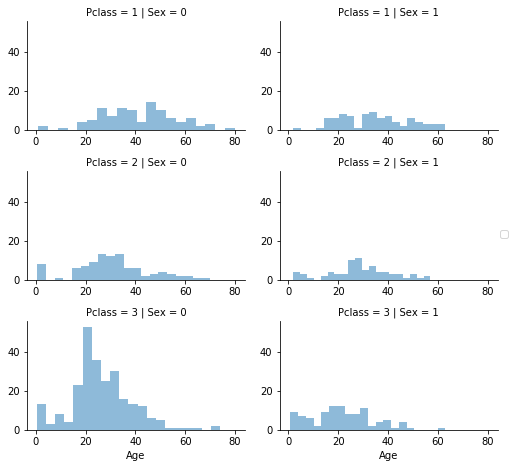

```python
grid = sns.FacetGrid(train_df, row='Pclass', col='Sex', size=2.2, aspect=1.6)
grid.map(plt.hist, 'Age', alpha=.5, bins=20)
grid.add_legend()
```

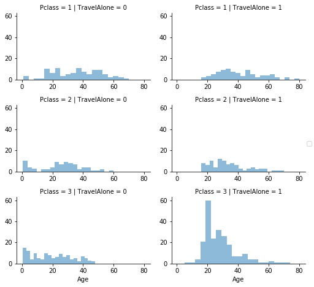

```python
# grid = sns.FacetGrid(train_df, col='Embarked')
grid = sns.FacetGrid(train_df, row='Pclass', col='TravelAlone', size=2.2, aspect=1.6)
grid.map(plt.hist, 'Age', alpha=.5, bins=20)
grid.add_legend()
```

Since class and gender can hardly tell whether the object is an adult or a child and so define his age, we would consider one more variable "TravelAlone" to help impute age indicate whether the person is or not a kid. (Children would is not likely to board on such a big boat as Titanic alone)

```python
guess_ages = np.zeros((2,2,3))
guess_ages
```

```
array([[[ 0.,  0.,  0.],
        [ 0.,  0.,  0.]],

       [[ 0.,  0.,  0.],
        [ 0.,  0.,  0.]]])
```

```python
for dataset in combine:
    for i in range(0, 2):
      for k in range(0, 2):
        for j in range(0, 3):
            guess_df = dataset[(dataset['Sex'] == i) & (dataset['TravelAlone'] == k) & \
                                  (dataset['Pclass'] == j+1)]['Age'].dropna()

            age_mean = guess_df.mean()
            age_std = guess_df.std()
            age_guess = rnd.uniform(age_mean - age_std, age_mean + age_std)

            age_guess = guess_df.median()

            # Convert random age float to nearest .5 age
            guess_ages[i,k,j] = int( age_guess/0.5 + 0.5 ) * 0.5

    for i in range(0, 2):
      for k in range(0, 2):
        for j in range(0, 3):
            dataset.loc[ (dataset.Age.isnull()) & (dataset.Sex == i) & (dataset.TravelAlone == k) & (dataset.Pclass == j+1),\
                    'Age'] = guess_ages[i,k,j]

    dataset['Age'] = dataset['Age'].astype(int)
```

#### Interactive Term: Class vs. Age

```python
for dataset in combine:
    dataset['Age*Class'] = dataset.Age * dataset.Pclass

train_df.loc[:, ['Age*Class', 'Age', 'Pclass']].head(10)
```

|  | Age*Class | Age | Pclass |
| --- | --- | --- | --- |
| 0 | 66 | 22 | 3 |
| 1 | 38 | 38 | 1 |
| 2 | 78 | 26 | 3 |
| 3 | 35 | 35 | 1 |
| 4 | 105 | 35 | 3 |
| 5 | 81 | 27 | 3 |
| 6 | 54 | 54 | 1 |
| 7 | 6 | 2 | 3 |
| 8 | 81 | 27 | 3 |
| 9 | 28 | 14 | 2 |

```python
freq_port = train_df.Embarked.dropna().mode()[0]
for dataset in combine:
    dataset['Embarked'] = dataset['Embarked'].fillna(freq_port)

train_df[['Embarked', 'Survived']].groupby(['Embarked'], as_index=False).mean().sort_values(by='Survived', ascending=False)
```

|  | Embarked | Survived |
| --- | --- | --- |
| 0 | C | 0.553571 |
| 1 | Q | 0.389610 |
| 2 | S | 0.339009 |

**Make sure there is no more NA**

```python
len(test_df) - test_df.count()
```

```
PassengerId    0
Pclass         0
Sex            0
Age            0
SibSp          0
Parch          0
Fare           1
Embarked       0
Title          0
FamilySize     0
TravelAlone    0
Age*Class      0
dtype: int64
```

```python
guess_fare = np.zeros((2,2,3))
guess_fare
```

```
array([[[ 0.,  0.,  0.],
        [ 0.,  0.,  0.]],

       [[ 0.,  0.,  0.],
        [ 0.,  0.,  0.]]])
```

```python
for dataset in combine:
    for i in range(0, 2):
      for k in range(0, 2):
        for j in range(0, 3):
            guess_df = dataset[(dataset['Sex'] == i) & (dataset['TravelAlone'] == k) & \
                                  (dataset['Pclass'] == j+1)]['Fare'].dropna()

            fare_mean = guess_df.mean()
            fare_std = guess_df.std()
            fare_guess = rnd.uniform(fare_mean - fare_std, fare_mean + fare_std)

            fare_guess = guess_df.median()

            # Convert random age float to nearest .5 age
            guess_fare[i,k,j] = int( fare_guess/0.5 + 0.5 ) * 0.5

    for i in range(0, 2):
      for k in range(0, 2):
        for j in range(0, 3):
            dataset.loc[ (dataset.Fare.isnull()) & (dataset.Sex == i) & (dataset.TravelAlone == k) & (dataset.Pclass == j+1),\
                    'Fare'] = guess_fare[i,k,j]

    #dataset['Fare'] = dataset['Fare'].astype(int)
```

```python
train_df.head()
```

|  | Survived | Pclass | Sex | Age | SibSp | Parch | Fare | Embarked | Title | FamilySize | TravelAlone | Age*Class |
| --- | --- | --- | --- | --- | --- | --- | --- | --- | --- | --- | --- | --- |
| 0 | 0 | 3 | 0 | 22 | 1 | 0 | 7.2500 | S | 1 | 2 | 0 | 66 |
| 1 | 1 | 1 | 1 | 38 | 1 | 0 | 71.2833 | C | 3 | 2 | 0 | 38 |
| 2 | 1 | 3 | 1 | 26 | 0 | 0 | 7.9250 | S | 2 | 1 | 1 | 78 |
| 3 | 1 | 1 | 1 | 35 | 1 | 0 | 53.1000 | S | 3 | 2 | 0 | 35 |
| 4 | 0 | 3 | 0 | 35 | 0 | 0 | 8.0500 | S | 1 | 1 | 1 | 105 |

There is one more observation in test set, Fare, need to be imputed. Here we would apply similiar method as we do on age.

```python
len(test_df) - test_df.count()
```

```
PassengerId    0
Pclass         0
Sex            0
Age            0
SibSp          0
Parch          0
Fare           0
Embarked       0
Title          0
FamilySize     0
TravelAlone    0
Age*Class      0
dtype: int64
```

**Converting categorical feature into Proper type**

We can now convert the EmbarkedFill feature by creating a new numeric Port feature.

```python
for dataset in combine:
    dataset['Embarked'] = dataset['Embarked'].map( {'S': 0, 'C': 1, 'Q': 2} ).astype(int)

train_df.head()
```

|  | Survived | Pclass | Sex | Age | SibSp | Parch | Fare | Embarked | Title | FamilySize | TravelAlone | Age*Class |
| --- | --- | --- | --- | --- | --- | --- | --- | --- | --- | --- | --- | --- |
| 0 | 0 | 3 | 0 | 22 | 1 | 0 | 7.2500 | 0 | 1 | 2 | 0 | 66 |
| 1 | 1 | 1 | 1 | 38 | 1 | 0 | 71.2833 | 1 | 3 | 2 | 0 | 38 |
| 2 | 1 | 3 | 1 | 26 | 0 | 0 | 7.9250 | 0 | 2 | 1 | 1 | 78 |
| 3 | 1 | 1 | 1 | 35 | 1 | 0 | 53.1000 | 0 | 3 | 2 | 0 | 35 |
| 4 | 0 | 3 | 0 | 35 | 0 | 0 | 8.0500 | 0 | 1 | 1 | 1 | 105 |

**Feature Transformation for Fare** There three procedure we can try for feature transformation:

- Standardized the variable, the simplest one but may provide limited change.
- Log transformation could help to deal with outlier
- Converting a numeric feature into ordinal feature

```python
from sklearn.preprocessing import scale

# Scale the features: X_scaled
fare_scaled = scale(train_df['Fare'])
```

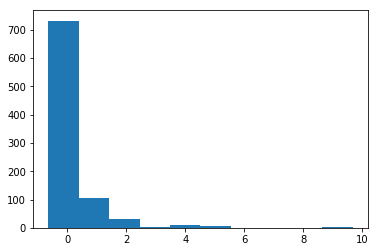

```python
plt.hist(fare_scaled)
```

```python
fare_log = np.log(train_df['Fare']+0.1)
```

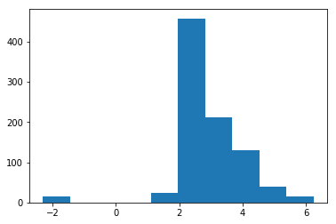

```python
plt.hist(fare_log)
```

We can see log transformation is better than normalization. However, could tranforming into ordinal feature fit better?

```python
train_df.describe()
```

|  | Survived | Pclass | Sex | Age | SibSp | Parch | Fare | Embarked | Title | FamilySize | TravelAlone | Age*Class |
| --- | --- | --- | --- | --- | --- | --- | --- | --- | --- | --- | --- | --- |
| count | 891.000000 | 891.000000 | 891.000000 | 891.000000 | 891.000000 | 891.000000 | 891.000000 | 891.000000 | 891.000000 | 891.000000 | 891.000000 | 891.000000 |
| mean | 0.383838 | 2.308642 | 0.352413 | 29.193042 | 0.523008 | 0.381594 | 32.204208 | 0.361392 | 1.728395 | 1.904602 | 0.602694 | 62.632997 |
| std | 0.486592 | 0.836071 | 0.477990 | 13.510994 | 1.102743 | 0.806057 | 49.693429 | 0.635673 | 1.030039 | 1.613459 | 0.489615 | 31.546630 |
| min | 0.000000 | 1.000000 | 0.000000 | 0.000000 | 0.000000 | 0.000000 | 0.000000 | 0.000000 | 1.000000 | 1.000000 | 0.000000 | 0.000000 |
| 25% | 0.000000 | 2.000000 | 0.000000 | 21.000000 | 0.000000 | 0.000000 | 7.910400 | 0.000000 | 1.000000 | 1.000000 | 0.000000 | 44.500000 |
| 50% | 0.000000 | 3.000000 | 0.000000 | 27.000000 | 0.000000 | 0.000000 | 14.454200 | 0.000000 | 1.000000 | 1.000000 | 1.000000 | 60.000000 |
| 75% | 1.000000 | 3.000000 | 1.000000 | 36.000000 | 1.000000 | 0.000000 | 31.000000 | 1.000000 | 2.000000 | 2.000000 | 1.000000 | 81.000000 |
| max | 1.000000 | 3.000000 | 1.000000 | 80.000000 | 8.000000 | 6.000000 | 512.329200 | 2.000000 | 5.000000 | 11.000000 | 1.000000 | 222.000000 |

```python
train_df['FareBand'] = pd.qcut(train_df['Fare'],10)
train_df[['FareBand', 'Survived']].groupby(['FareBand'], as_index=False).mean().sort_values(by='FareBand', ascending=True)
```

|  | FareBand | Survived |
| --- | --- | --- |
| 0 | (-0.001, 7.55] | 0.141304 |
| 1 | (7.55, 7.854] | 0.298851 |
| 2 | (7.854, 8.05] | 0.179245 |
| 3 | (8.05, 10.5] | 0.230769 |
| 4 | (10.5, 14.454] | 0.428571 |
| 5 | (14.454, 21.679] | 0.420455 |
| 6 | (21.679, 27.0] | 0.516854 |
| 7 | (27.0, 39.688] | 0.373626 |
| 8 | (39.688, 77.958] | 0.528090 |
| 9 | (77.958, 512.329] | 0.758621 |

```python
for dataset in combine:
    dataset.loc[(dataset['Fare'] <= 10.5), 'Fare'] = 0
    dataset.loc[(dataset['Fare'] > 10.5) & (dataset['Fare'] <= 39.688), 'Fare']   = 1
    dataset.loc[(dataset['Fare'] > 39.688) & (dataset['Fare'] <= 500), 'Fare']   = 2
    dataset.loc[ dataset['Fare'] > 500, 'Fare'] = 3
    dataset['Fare'] = dataset['Fare'].astype(int)
```

```python
train_df = train_df.drop(['FareBand'], axis=1)
combine = [train_df, test_df]

train_df.head(10)
```

|  | Survived | Pclass | Sex | Age | SibSp | Parch | Fare | Embarked | Title | FamilySize | TravelAlone | Age*Class |
| --- | --- | --- | --- | --- | --- | --- | --- | --- | --- | --- | --- | --- |
| 0 | 0 | 3 | 0 | 22 | 1 | 0 | 0 | 0 | 1 | 2 | 0 | 66 |
| 1 | 1 | 1 | 1 | 38 | 1 | 0 | 2 | 1 | 3 | 2 | 0 | 38 |
| 2 | 1 | 3 | 1 | 26 | 0 | 0 | 0 | 0 | 2 | 1 | 1 | 78 |
| 3 | 1 | 1 | 1 | 35 | 1 | 0 | 2 | 0 | 3 | 2 | 0 | 35 |
| 4 | 0 | 3 | 0 | 35 | 0 | 0 | 0 | 0 | 1 | 1 | 1 | 105 |
| 5 | 0 | 3 | 0 | 27 | 0 | 0 | 0 | 2 | 1 | 1 | 1 | 81 |
| 6 | 0 | 1 | 0 | 54 | 0 | 0 | 2 | 0 | 1 | 1 | 1 | 54 |
| 7 | 0 | 3 | 0 | 2 | 3 | 1 | 1 | 0 | 4 | 5 | 0 | 6 |
| 8 | 1 | 3 | 1 | 27 | 0 | 2 | 1 | 0 | 3 | 3 | 0 | 81 |
| 9 | 1 | 2 | 1 | 14 | 1 | 0 | 1 | 1 | 3 | 2 | 0 | 28 |

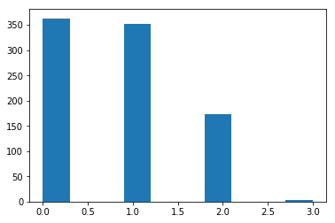

```python
plt.hist(train_df['Fare'])
```

The histgram is not perfert though after transforming numeric fare in to ordinal one.

### Modeling

```python
from sklearn.preprocessing import StandardScaler
from sklearn.pipeline import Pipeline
from sklearn.model_selection import train_test_split
from sklearn.model_selection import GridSearchCV
from sklearn.metrics import classification_report
from sklearn.metrics import confusion_matrix
from sklearn.metrics import accuracy_score
from sklearn.model_selection import cross_val_score
```

```python
X_Train = train_df.drop("Survived", axis=1)
Y_Train = train_df["Survived"]
X_predict  = test_df.drop("PassengerId", axis=1).copy()
X_Train.shape, Y_Train.shape, X_predict.shape
```

```
((891, 11), (891,), (418, 11))
```

```python
X_train, X_test, y_train, y_test = train_test_split(X_Train,Y_Train,test_size = 0.2,random_state = 123)
X_train.shape, X_test.shape, y_train.shape, y_test.shape
```

```
((712, 11), (179, 11), (712,), (179,))
```

#### SVM

```python
steps = [('SVM', SVC())]

pipeline = Pipeline(steps)

# Specify the hyperparameter space
parameters = {'SVM__C':[1, 10, 100],
              'SVM__gamma':[0.1, 0.01]}
```

```python
# Instantiate the GridSearchCV object: cv
cv = GridSearchCV(pipeline,parameters)

# Fit to the training set
cv.fit(X_train,y_train)

# Predict the labels of the test set: y_pred
y_pred = cv.predict(X_test)

# Compute and print metrics
print("Accuracy: {}".format(cv.score(X_test, y_test)))
print(classification_report(y_test, y_pred))
print("Tuned Model Parameters: {}".format(cv.best_params_))
acc_svc = cv.score(X_test, y_test)
```

```
Accuracy: 0.8100558659217877
             precision    recall  f1-score   support

          0       0.84      0.86      0.85       114
          1       0.75      0.72      0.73        65

avg / total       0.81      0.81      0.81       179

Tuned Model Parameters: {'SVM__C': 10, 'SVM__gamma': 0.01}
```

```python
# Support Vector Machines

svc = SVC(C = 10, gamma = 0.01)
svc.fit(X_Train, Y_Train)
svc_Y_pred = svc.predict(X_predict)
svc_Y_pred
```

```
array([0, 0, 1, 0, 1, 0, 0, 0, 1, 0, 0, 0, 1, 1, 1, 1, 0, 0, 0, 0, 0, 1, 1,
       0, 1, 0, 1, 0, 0, 0, 0, 0, 1, 1, 1, 0, 0, 1, 0, 0, 0, 0, 0, 1, 1, 0,
       0, 0, 1, 1, 1, 0, 1, 1, 0, 0, 0, 0, 0, 1, 0, 0, 0, 1, 1, 1, 1, 0, 1,
       1, 1, 0, 0, 1, 1, 1, 0, 1, 0, 1, 1, 0, 0, 0, 0, 0, 0, 1, 1, 1, 1, 0,
       1, 0, 1, 0, 1, 0, 1, 0, 1, 0, 0, 0, 1, 0, 0, 0, 0, 0, 0, 1, 1, 1, 1,
       0, 0, 1, 1, 1, 1, 0, 1, 0, 0, 1, 0, 1, 0, 0, 0, 1, 0, 0, 0, 0, 0, 0,
       0, 0, 0, 1, 0, 0, 0, 0, 0, 0, 0, 1, 1, 0, 0, 1, 0, 0, 1, 0, 0, 1, 1,
       1, 1, 0, 1, 1, 0, 0, 1, 0, 0, 0, 0, 0, 0, 1, 1, 0, 1, 1, 0, 1, 1, 0,
       1, 0, 1, 0, 0, 0, 0, 0, 1, 1, 1, 0, 1, 1, 0, 1, 1, 1, 1, 1, 0, 0, 0,
       0, 1, 0, 0, 0, 0, 0, 1, 0, 1, 0, 1, 0, 1, 0, 1, 0, 1, 1, 0, 1, 0, 0,
       0, 1, 0, 0, 1, 0, 0, 0, 1, 1, 1, 1, 0, 0, 1, 1, 1, 0, 1, 1, 1, 0, 1,
       0, 0, 0, 0, 0, 1, 0, 0, 0, 1, 1, 0, 0, 0, 0, 0, 0, 0, 0, 1, 1, 0, 1,
       0, 0, 0, 0, 0, 1, 1, 0, 1, 0, 0, 1, 0, 0, 0, 0, 0, 1, 0, 0, 1, 0, 1,
       0, 0, 0, 0, 0, 1, 1, 0, 1, 0, 0, 0, 0, 0, 0, 1, 1, 0, 0, 0, 0, 0, 0,
       0, 1, 1, 0, 1, 0, 0, 0, 1, 1, 0, 1, 0, 1, 0, 0, 0, 1, 0, 0, 0, 1, 1,
       1, 0, 0, 0, 1, 1, 0, 0, 1, 1, 0, 1, 0, 0, 0, 0, 1, 1, 0, 1, 0, 0, 1,
       1, 0, 0, 1, 0, 0, 1, 1, 0, 0, 0, 0, 0, 0, 1, 1, 0, 1, 0, 0, 0, 0, 1,
       1, 1, 0, 0, 1, 0, 1, 0, 0, 1, 0, 1, 1, 0, 0, 0, 0, 1, 1, 1, 1, 0, 0,
       1, 0, 0, 1])
```

#### KNN

```python
#Tuning parameter K
# Setup arrays to store train and test accuracies
neighbors = np.arange(1, 9)
train_accuracy = np.empty(len(neighbors))
test_accuracy = np.empty(len(neighbors))

# Loop over different values of k
for i, k in enumerate(neighbors):
    # Setup a k-NN Classifier with k neighbors: knn
    knn = KNeighborsClassifier(n_neighbors=k)

    # Fit the classifier to the training data
    knn.fit(X_train,y_train)

    #Compute accuracy on the training set
    train_accuracy[i] = knn.score(X_train, y_train)

    #Compute accuracy on the testing set
    test_accuracy[i] = knn.score(X_test, y_test)
```

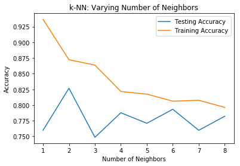

```python
# Generate plot
plt.title('k-NN: Varying Number of Neighbors')
plt.plot(neighbors, test_accuracy, label = 'Testing Accuracy')
plt.plot(neighbors, train_accuracy, label = 'Training Accuracy')
plt.legend()
plt.xlabel('Number of Neighbors')
plt.ylabel('Accuracy')
plt.show()
```

```python
n = 2
knn = KNeighborsClassifier(n_neighbors= n)
```

```python
# Fit the classifier to the training data
knn.fit(X_train,y_train)

# Predict the labels of the test data: y_pred
y_pred = knn.predict(X_test)

# Generate the confusion matrix and classification report
print("Accuracy: {}".format(knn.score(X_test, y_test)))
print(confusion_matrix(y_test,y_pred))
print(classification_report(y_test,y_pred))
print("KNN Neighbors = {}".format(n))
acc_knn = knn.score(X_test, y_test)
```

```
Accuracy: 0.8268156424581006
[[108   6]
 [ 25  40]]
             precision    recall  f1-score   support

          0       0.81      0.95      0.87       114
          1       0.87      0.62      0.72        65

avg / total       0.83      0.83      0.82       179

KNN Neighbors = 2
```

```python
knn.fit(X_Train,Y_Train)
knn_Y_pred = knn.predict(X_predict)
knn_Y_pred
```

```
array([0, 0, 0, 0, 0, 0, 0, 0, 0, 0, 0, 0, 1, 0, 1, 0, 0, 0, 0, 0, 0, 1, 1,
       0, 0, 0, 1, 0, 0, 0, 0, 0, 0, 0, 0, 0, 0, 0, 0, 0, 0, 1, 0, 0, 1, 0,
       0, 0, 0, 0, 1, 0, 0, 0, 0, 0, 0, 0, 0, 0, 0, 0, 0, 0, 1, 1, 0, 0, 0,
       0, 0, 0, 0, 1, 1, 1, 0, 1, 0, 0, 1, 0, 0, 0, 0, 0, 0, 1, 0, 1, 0, 0,
       0, 0, 0, 0, 0, 0, 0, 0, 1, 0, 0, 0, 0, 0, 0, 0, 0, 0, 1, 0, 1, 0, 1,
       0, 0, 1, 0, 1, 1, 0, 1, 0, 0, 0, 0, 0, 0, 0, 0, 1, 0, 0, 0, 0, 0, 0,
       0, 0, 0, 1, 0, 0, 1, 0, 1, 0, 1, 1, 1, 0, 0, 0, 0, 0, 1, 0, 1, 0, 0,
       0, 0, 0, 0, 0, 0, 0, 1, 0, 0, 0, 0, 0, 0, 0, 1, 0, 0, 0, 0, 0, 1, 0,
       0, 0, 0, 0, 0, 0, 0, 1, 0, 0, 1, 0, 1, 1, 0, 0, 0, 1, 1, 1, 0, 1, 0,
       0, 1, 0, 0, 0, 0, 0, 0, 1, 0, 0, 1, 0, 0, 0, 1, 0, 1, 1, 0, 0, 0, 0,
       1, 1, 0, 0, 1, 0, 0, 0, 1, 1, 0, 1, 0, 0, 1, 0, 1, 0, 1, 1, 1, 0, 0,
       0, 0, 0, 0, 0, 0, 0, 0, 0, 1, 1, 0, 0, 1, 0, 0, 0, 0, 0, 1, 0, 0, 0,
       0, 1, 0, 0, 0, 1, 0, 0, 0, 0, 0, 1, 0, 0, 1, 0, 0, 1, 0, 0, 0, 0, 0,
       0, 0, 0, 0, 0, 0, 0, 0, 1, 0, 0, 0, 0, 0, 0, 1, 0, 0, 0, 0, 0, 0, 0,
       0, 0, 1, 0, 0, 0, 0, 0, 0, 0, 0, 0, 0, 0, 0, 0, 0, 0, 0, 0, 0, 1, 1,
       0, 0, 0, 0, 0, 1, 0, 0, 1, 1, 0, 1, 0, 0, 0, 0, 1, 1, 0, 1, 0, 0, 0,
       1, 0, 0, 1, 0, 0, 1, 0, 0, 0, 0, 0, 0, 0, 0, 1, 0, 1, 0, 0, 0, 0, 0,
       1, 1, 0, 0, 1, 0, 1, 0, 0, 1, 0, 1, 0, 0, 0, 0, 0, 0, 1, 0, 1, 0, 0,
       0, 0, 0, 1])
```

#### Logistic Regression

**Hyperparameters tuning:GridSearch CV**

```python
# Create the hyperparameter grid
c_space = np.logspace(-5, 8, 15)
param_grid = {'C': c_space, 'penalty': ['l1', 'l2']}

# Instantiate the logistic regression classifier: logreg
logreg = LogisticRegression()

# Create train and test sets

# Instantiate the GridSearchCV object: logreg_cv
logreg_cv = GridSearchCV(logreg,param_grid,cv = 5)

# Fit it to the training data
logreg_cv.fit(X_train,y_train)
```

```
GridSearchCV(cv=5, error_score='raise',
       estimator=LogisticRegression(C=1.0, class_weight=None, dual=False, fit_intercept=True,
          intercept_scaling=1, max_iter=100, multi_class='ovr', n_jobs=1,
          penalty='l2', random_state=None, solver='liblinear', tol=0.0001,
          verbose=0, warm_start=False),
       fit_params=None, iid=True, n_jobs=1,
       param_grid={'C': array([  1.00000e-05,   8.48343e-05,   7.19686e-04,   6.10540e-03,
         5.17947e-02,   4.39397e-01,   3.72759e+00,   3.16228e+01,
         2.68270e+02,   2.27585e+03,   1.93070e+04,   1.63789e+05,
         1.38950e+06,   1.17877e+07,   1.00000e+08]), 'penalty': ['l1', 'l2']},
       pre_dispatch='2*n_jobs', refit=True, return_train_score='warn',
       scoring=None, verbose=0)
```

```python
y_pred = logreg_cv.predict(X_test)

# Compute and print metrics
print("Accuracy: {}".format(cv.score(X_test, y_test)))
print(classification_report(y_test, y_pred))


# Print the optimal parameters and best score
print("Tuned Logistic Regression Parameter: {}".format(logreg_cv.best_params_))
print("Tuned Logistic Regression Accuracy: {}".format(logreg_cv.best_score_))
```

```
Accuracy: 0.8100558659217877
             precision    recall  f1-score   support

          0       0.87      0.85      0.86       114
          1       0.75      0.77      0.76        65

avg / total       0.82      0.82      0.82       179

Tuned Logistic Regression Parameter: {'C': 0.43939705607607948, 'penalty': 'l2'}
Tuned Logistic Regression Accuracy: 0.8202247191011236
```

```python
from sklearn.feature_selection import f_regression
logreg = LogisticRegression(**logreg_cv.best_params_)

# Fit it to the training data
logreg.fit(X_train,y_train)
y_pred = logreg.predict(X_test)
print(logreg.score(X_test,y_test))
#Coefficient report
coeff_df = pd.DataFrame(train_df.columns.delete(0))
coeff_df.columns = ['Feature']
coeff_df["Correlation"] = pd.Series(logreg.coef_[0])
coeff_df["P-value"] = pd.Series(f_regression(X_train, y_train)[1])
coeff_df.sort_values(by='P-value', ascending=True)
```

```
0.821229050279
```

|  | Feature | Correlation | P-value |
| --- | --- | --- | --- |
| 1 | Sex | 1.949541 | 7.608019e-55 |
| 7 | Title | 0.502046 | 2.333057e-32 |
| 10 | Age*Class | -0.016418 | 3.960813e-21 |
| 5 | Fare | 0.406380 | 3.257972e-19 |
| 0 | Pclass | -0.359205 | 9.090340e-19 |
| 9 | TravelAlone | -0.401192 | 2.496457e-09 |
| 4 | Parch | -0.059618 | 4.607478e-03 |
| 6 | Embarked | 0.092223 | 8.867721e-03 |
| 2 | Age | -0.007954 | 3.058179e-02 |
| 3 | SibSp | -0.482609 | 4.083831e-01 |
| 8 | FamilySize | -0.166533 | 4.358790e-01 |

```python
#Comparison without Hyperparameters tuning

logreg = LogisticRegression()
logreg.fit(X_train, y_train)
print(logreg.score(X_test, y_test))
acc_log = logreg.score(X_test, y_test)
```

```
0.826815642458
```

Interestingly, the default set for cost and penalty perform better. Perhaps due to the lack of samples, we can not see a significant benefits for parameters tuning.

Here we will use default set (with C = 1 and penalty = l2) of Logistic Regression instead.

```python
logreg = LogisticRegression()
logreg.fit(X_Train,Y_Train)
logreg_Y_pred = logreg.predict(X_predict)
logreg_Y_pred
```

```
array([0, 0, 0, 0, 1, 0, 1, 0, 1, 0, 0, 0, 1, 0, 1, 1, 0, 0, 0, 0, 0, 0, 1,
       1, 1, 0, 1, 0, 0, 0, 0, 0, 0, 1, 0, 0, 1, 1, 0, 0, 0, 0, 0, 1, 1, 0,
       0, 0, 1, 1, 0, 0, 1, 1, 0, 0, 0, 0, 0, 1, 0, 0, 0, 1, 1, 1, 1, 0, 0,
       1, 1, 0, 1, 0, 1, 1, 0, 1, 0, 1, 1, 0, 0, 0, 0, 0, 1, 1, 1, 1, 1, 0,
       1, 0, 0, 0, 1, 0, 1, 0, 1, 0, 0, 0, 1, 0, 0, 0, 0, 0, 0, 1, 1, 1, 1,
       0, 0, 1, 1, 1, 1, 0, 1, 0, 0, 1, 0, 1, 0, 0, 0, 1, 1, 0, 0, 0, 0, 0,
       1, 0, 0, 1, 0, 0, 0, 0, 0, 0, 0, 0, 1, 0, 0, 1, 0, 0, 1, 1, 0, 1, 1,
       0, 1, 0, 1, 1, 0, 0, 1, 1, 0, 0, 0, 0, 0, 1, 1, 0, 1, 1, 0, 0, 1, 0,
       1, 0, 1, 0, 0, 0, 0, 0, 0, 0, 1, 0, 1, 1, 0, 1, 1, 1, 1, 1, 0, 0, 1,
       0, 1, 0, 0, 0, 0, 1, 0, 0, 1, 0, 1, 0, 1, 0, 1, 0, 1, 1, 0, 1, 0, 0,
       0, 1, 0, 0, 0, 0, 0, 0, 1, 1, 1, 1, 0, 0, 0, 0, 1, 0, 1, 1, 1, 0, 1,
       0, 0, 0, 0, 0, 1, 0, 0, 0, 1, 1, 0, 0, 0, 0, 1, 0, 0, 0, 1, 1, 0, 1,
       0, 0, 0, 0, 1, 1, 1, 1, 1, 0, 0, 0, 0, 0, 0, 1, 0, 1, 0, 0, 1, 0, 1,
       0, 0, 0, 0, 0, 1, 1, 0, 1, 0, 0, 0, 0, 0, 1, 1, 1, 0, 0, 0, 0, 0, 0,
       0, 0, 1, 0, 1, 0, 0, 0, 1, 0, 0, 1, 0, 0, 0, 0, 0, 0, 0, 0, 0, 1, 0,
       1, 0, 1, 0, 1, 1, 0, 0, 0, 1, 0, 1, 0, 0, 1, 0, 1, 1, 0, 1, 0, 0, 1,
       1, 0, 0, 1, 0, 0, 1, 1, 0, 0, 0, 0, 0, 0, 1, 1, 0, 1, 0, 0, 0, 0, 1,
       1, 0, 0, 0, 1, 0, 1, 0, 0, 1, 0, 1, 1, 0, 0, 0, 0, 1, 1, 1, 1, 1, 0,
       1, 0, 0, 0])
```

#### Decision Tree

```python
from scipy.stats import randint
from sklearn.model_selection import RandomizedSearchCV
```

**Hyperparameters tuning:RandomizedSearchCV**

```python
# Setup the parameters and distributions to sample from: param_dist
param_dist = {"max_depth": [3, None],
              "max_features": randint(1, 9),
              "min_samples_leaf": randint(1, 9),
              "criterion": ["gini", "entropy"]}

# Instantiate a Decision Tree classifier: tree
tree = DecisionTreeClassifier()

# Instantiate the RandomizedSearchCV object: tree_cv
tree_cv = RandomizedSearchCV(tree,param_dist , cv=5)

# Fit it to the data
tree_cv.fit(X_train,y_train)

# Print the tuned parameters and score
print("Tuned Decision Tree Parameters: {}".format(tree_cv.best_params_))
print("Best score is {}".format(tree_cv.best_score_))
print("Test Accuracy is {}".format(tree_cv.score(X_test,y_test)))
```

```
Tuned Decision Tree Parameters: {'criterion': 'entropy', 'max_depth': 3, 'max_features': 6, 'min_samples_leaf': 8}
Best score is 0.8174157303370787
Test Accuracy is 0.8379888268156425
```

**Hyperparameters tuning:GridSearch CV**

```python
# Setup the parameters and distributions to sample from: param_dist
param_grid = {"max_depth": [3, None],
              "max_features": range(1, 9),
              "min_samples_leaf": range(1, 9),
              "criterion": ["gini", "entropy"]}

# Instantiate a Decision Tree classifier: tree
tree = DecisionTreeClassifier(random_state = 123)

# Instantiate the RandomizedSearchCV object: tree_cv
tree_cv = GridSearchCV(tree,param_grid, cv=5)

# Fit it to the data
tree_cv.fit(X_train,y_train)

# Print the tuned parameters and score
print("Tuned Decision Tree Parameters: {}".format(tree_cv.best_params_))
print("Best score is {}".format(tree_cv.best_score_))
print("Test Accuracy is {}".format(tree_cv.score(X_test,y_test)))
acc_decision_tree = tree_cv.score(X_test,y_test)
```

```
Tuned Decision Tree Parameters: {'criterion': 'gini', 'max_depth': None, 'max_features': 7, 'min_samples_leaf': 8}
Best score is 0.8216292134831461
Test Accuracy is 0.8379888268156425
```

RandomizedSearchCV will never outperform GridSearchCV. Instead, it is valuable because it saves on computation time

However, since the Titanic dateset is small, we would aim for higher accuracy and use GridSearchCV

```python
tree = DecisionTreeClassifier(**tree_cv.best_params_)
tree.fit(X_Train,Y_Train)
tree_Y_pred = tree.predict(X_predict)
tree_Y_pred
```

```
array([0, 0, 0, 0, 0, 0, 0, 0, 0, 0, 0, 0, 1, 0, 1, 1, 0, 0, 0, 0, 0, 1, 1,
       0, 1, 0, 1, 0, 0, 0, 0, 0, 0, 0, 0, 0, 1, 1, 0, 0, 0, 0, 0, 1, 1, 0,
       0, 0, 1, 0, 0, 0, 1, 1, 0, 0, 0, 0, 0, 1, 0, 0, 0, 1, 1, 1, 1, 0, 0,
       1, 1, 0, 0, 1, 1, 0, 0, 1, 0, 1, 1, 0, 1, 0, 0, 0, 1, 0, 1, 1, 0, 0,
       1, 0, 1, 0, 1, 0, 0, 0, 1, 0, 0, 0, 0, 0, 0, 0, 0, 0, 0, 1, 1, 1, 1,
       0, 0, 1, 1, 1, 1, 0, 1, 0, 0, 0, 0, 1, 0, 0, 0, 1, 0, 0, 0, 0, 0, 0,
       1, 0, 0, 1, 0, 0, 0, 0, 0, 0, 0, 0, 1, 0, 0, 0, 0, 0, 1, 1, 0, 1, 1,
       1, 1, 0, 0, 0, 1, 0, 1, 1, 0, 0, 0, 0, 0, 1, 1, 0, 1, 1, 0, 0, 1, 0,
       1, 0, 1, 0, 0, 0, 0, 0, 1, 0, 1, 0, 1, 0, 0, 1, 1, 1, 1, 1, 0, 0, 0,
       0, 1, 0, 0, 0, 0, 1, 0, 0, 1, 0, 1, 0, 1, 0, 1, 0, 1, 1, 0, 1, 0, 0,
       0, 1, 0, 0, 0, 0, 0, 0, 1, 1, 1, 1, 0, 0, 1, 0, 1, 0, 1, 0, 1, 0, 1,
       0, 0, 0, 0, 0, 1, 0, 0, 0, 1, 1, 0, 0, 0, 0, 1, 0, 0, 0, 1, 1, 0, 1,
       0, 0, 0, 0, 1, 1, 1, 0, 1, 0, 0, 0, 0, 0, 0, 0, 0, 1, 0, 0, 1, 0, 0,
       0, 0, 0, 0, 0, 1, 1, 0, 1, 0, 0, 0, 0, 0, 0, 1, 1, 0, 0, 0, 0, 0, 0,
       0, 0, 1, 0, 1, 0, 0, 0, 1, 0, 0, 0, 0, 0, 0, 0, 0, 1, 0, 0, 0, 1, 1,
       0, 0, 0, 0, 1, 1, 0, 0, 0, 1, 1, 1, 0, 0, 0, 0, 1, 1, 0, 1, 0, 0, 1,
       1, 0, 0, 1, 1, 0, 1, 1, 0, 0, 0, 0, 0, 0, 1, 0, 0, 1, 0, 0, 0, 0, 0,
       1, 1, 0, 0, 1, 0, 1, 0, 0, 1, 0, 1, 0, 0, 0, 0, 1, 1, 1, 1, 1, 0, 0,
       1, 0, 0, 1])
```

#### Random Forest

```python
random_forest = RandomForestClassifier(n_estimators=100,random_state = 123)
random_forest.fit(X_train, y_train)
acc_random_forest = random_forest.score(X_test, y_test)
acc_random_forest
```

```
0.81564245810055869
```

```python
random_forest.fit(X_Train,Y_Train)
rf_Y_pred = tree.predict(X_predict)
rf_Y_pred
```

```
array([0, 0, 0, 0, 0, 0, 0, 0, 0, 0, 0, 0, 1, 0, 1, 1, 0, 0, 0, 0, 0, 1, 1,
       0, 1, 0, 1, 0, 0, 0, 0, 0, 0, 0, 0, 0, 1, 1, 0, 0, 0, 0, 0, 1, 1, 0,
       0, 0, 1, 0, 0, 0, 1, 1, 0, 0, 0, 0, 0, 1, 0, 0, 0, 1, 1, 1, 1, 0, 0,
       1, 1, 0, 0, 1, 1, 0, 0, 1, 0, 1, 1, 0, 1, 0, 0, 0, 1, 0, 1, 1, 0, 0,
       1, 0, 1, 0, 1, 0, 0, 0, 1, 0, 0, 0, 0, 0, 0, 0, 0, 0, 0, 1, 1, 1, 1,
       0, 0, 1, 1, 1, 1, 0, 1, 0, 0, 0, 0, 1, 0, 0, 0, 1, 0, 0, 0, 0, 0, 0,
       1, 0, 0, 1, 0, 0, 0, 0, 0, 0, 0, 0, 1, 0, 0, 0, 0, 0, 1, 1, 0, 1, 1,
       1, 1, 0, 0, 0, 1, 0, 1, 1, 0, 0, 0, 0, 0, 1, 1, 0, 1, 1, 0, 0, 1, 0,
       1, 0, 1, 0, 0, 0, 0, 0, 1, 0, 1, 0, 1, 0, 0, 1, 1, 1, 1, 1, 0, 0, 0,
       0, 1, 0, 0, 0, 0, 1, 0, 0, 1, 0, 1, 0, 1, 0, 1, 0, 1, 1, 0, 1, 0, 0,
       0, 1, 0, 0, 0, 0, 0, 0, 1, 1, 1, 1, 0, 0, 1, 0, 1, 0, 1, 0, 1, 0, 1,
       0, 0, 0, 0, 0, 1, 0, 0, 0, 1, 1, 0, 0, 0, 0, 1, 0, 0, 0, 1, 1, 0, 1,
       0, 0, 0, 0, 1, 1, 1, 0, 1, 0, 0, 0, 0, 0, 0, 0, 0, 1, 0, 0, 1, 0, 0,
       0, 0, 0, 0, 0, 1, 1, 0, 1, 0, 0, 0, 0, 0, 0, 1, 1, 0, 0, 0, 0, 0, 0,
       0, 0, 1, 0, 1, 0, 0, 0, 1, 0, 0, 0, 0, 0, 0, 0, 0, 1, 0, 0, 0, 1, 1,
       0, 0, 0, 0, 1, 1, 0, 0, 0, 1, 1, 1, 0, 0, 0, 0, 1, 1, 0, 1, 0, 0, 1,
       1, 0, 0, 1, 1, 0, 1, 1, 0, 0, 0, 0, 0, 0, 1, 0, 0, 1, 0, 0, 0, 0, 0,
       1, 1, 0, 0, 1, 0, 1, 0, 0, 1, 0, 1, 0, 0, 0, 0, 1, 1, 1, 1, 1, 0, 0,
       1, 0, 0, 1])
```

#### Naive Bayes

```python
# Gaussian Naive Bayes

nb = GaussianNB()
nb_cvscores_5 = cross_val_score(nb,X_train,y_train,cv = 5)

#Compute accuracy on the training set
cv_train_accuracy = np.mean(nb_cvscores_5)

# Fit the classifier to the training data
nb.fit(X_train,y_train)

#Compute accuracy on the testing set
acc_gaussian = nb.score(X_test, y_test)
print(cv_train_accuracy)
print(acc_gaussian)
```

```
0.794947306215
0.77094972067
```

```python
nb = GaussianNB()
nb.fit(X_Train,Y_Train)
nb_Y_pred = nb.predict(X_predict)
nb_Y_pred
```

```
array([0, 0, 0, 0, 1, 0, 1, 0, 1, 0, 0, 0, 1, 0, 1, 1, 0, 0, 1, 0, 1, 1, 1,
       1, 1, 0, 1, 0, 0, 0, 0, 0, 1, 1, 1, 0, 1, 1, 0, 0, 0, 0, 0, 1, 1, 0,
       0, 0, 1, 1, 1, 0, 1, 0, 0, 0, 0, 0, 0, 1, 0, 0, 0, 1, 1, 1, 1, 1, 1,
       1, 1, 0, 0, 1, 1, 1, 0, 1, 0, 1, 1, 1, 0, 0, 0, 0, 1, 1, 1, 1, 1, 0,
       1, 0, 1, 0, 1, 0, 1, 0, 1, 0, 0, 0, 1, 0, 0, 0, 0, 0, 0, 1, 1, 1, 1,
       0, 0, 1, 1, 1, 1, 0, 1, 0, 0, 1, 0, 1, 0, 0, 0, 1, 1, 0, 0, 0, 0, 0,
       1, 0, 0, 1, 0, 0, 0, 0, 1, 0, 0, 1, 1, 0, 0, 1, 0, 0, 1, 1, 0, 1, 1,
       1, 1, 0, 1, 1, 1, 0, 1, 1, 0, 0, 0, 0, 0, 1, 1, 1, 1, 1, 0, 1, 1, 0,
       1, 0, 1, 0, 0, 0, 0, 0, 1, 0, 1, 0, 1, 1, 0, 1, 1, 1, 1, 1, 0, 0, 1,
       0, 1, 0, 0, 0, 0, 1, 0, 1, 1, 1, 1, 0, 1, 0, 1, 0, 1, 1, 0, 1, 0, 0,
       0, 1, 0, 0, 1, 0, 1, 0, 1, 1, 1, 1, 1, 0, 1, 1, 1, 0, 1, 1, 1, 0, 1,
       0, 0, 0, 0, 0, 1, 0, 0, 0, 1, 1, 0, 0, 0, 0, 1, 0, 1, 0, 1, 1, 0, 1,
       0, 0, 0, 0, 1, 1, 1, 1, 1, 0, 0, 1, 0, 0, 0, 1, 0, 1, 0, 0, 1, 0, 1,
       0, 0, 0, 0, 0, 1, 1, 1, 1, 1, 1, 0, 0, 0, 0, 1, 1, 1, 0, 0, 0, 0, 0,
       0, 0, 1, 0, 1, 1, 0, 0, 1, 0, 0, 1, 0, 0, 0, 0, 0, 0, 0, 0, 0, 1, 1,
       1, 0, 1, 0, 1, 1, 0, 0, 0, 1, 0, 1, 0, 0, 1, 0, 1, 1, 0, 1, 0, 0, 1,
       1, 0, 0, 1, 0, 0, 1, 1, 0, 0, 1, 0, 0, 0, 1, 1, 0, 1, 0, 0, 0, 0, 1,
       1, 1, 0, 0, 1, 0, 1, 0, 0, 1, 0, 1, 1, 1, 0, 0, 1, 1, 1, 1, 1, 0, 0,
       1, 0, 0, 1])
```

### **Model Comparison**

```python
models = pd.DataFrame({
    'Model': ['Support Vector Machines', 'KNN', 'Logistic Regression',
              'Random Forest', 'Naive Bayes','Decision Tree'],
    'Score': [acc_svc, acc_knn, acc_log,
              acc_random_forest, acc_gaussian, acc_decision_tree]})
models.sort_values(by='Score', ascending=False)
```

|  | Model | Score |
| --- | --- | --- |
| 5 | Decision Tree | 0.837989 |
| 1 | KNN | 0.826816 |
| 2 | Logistic Regression | 0.826816 |
| 3 | Random Forest | 0.815642 |
| 0 | Support Vector Machines | 0.810056 |
| 4 | Naive Bayes | 0.770950 |

```python
submission = pd.DataFrame({
        "PassengerId": test_df["PassengerId"],
        "Survived": knn_Y_pred
    })
submission.to_csv('knn_submission.csv', index=False)
```

```python
from google.colab import files
files.download("knn_submission.csv")
```